# Test of Perceptual Phenomenon

### Inferential Statistics: Stroop Task

#### Background Information

In a Stroop task, participants are presented with a list of words, with each word displayed in a color of ink. The participant’s task is to say out loud the color of the ink in which the word is printed. The task has two conditions: a congruent words condition, and an incongruent words condition. In the congruent words condition, the words being displayed are color words whose names match the colors in which they are printed: for example RED, BLUE. In the incongruent words condition, the words displayed are color words whose names do not match the colors in which they are printed: for example PURPLE, ORANGE. In each case, we measure the time it takes to name the ink colors in equally-sized lists. Each participant will go through and record a time from each condition.

#### Questions for Investigation

As a general note, be sure to keep a record of any resources that you use or refer to in the creation of your project. You will need to report your sources as part of the project submission.

#### 1. What is our independent variable? What is our dependent variable?

In our investigation the independent variable is the set of conditions for the Stroop Test, including word-to-text color congruent and incongruent conditions. The dependent variable is the time taken to complete the test for each individual.

#### 2. What is an appropriate set of hypotheses for this task? What kind of statistical test do you expect to perform? Justify your choices.

This task will show the null hypothesis designed such that it will be rejected if there is a significant difference in the mean response time of each sample population for the two conditions under investigation. Random variation explains observable differences in this model.

Represented mathematically as follows:

```
H0: μC = μI
```

Where:

```
H0 = Null hypothesis.
μC = The population mean response time under the congruent condition.
μI = The population mean response time under the incongruent condition.
```

At initial review the mean for each condition appears fairly different, 14.05 seconds for the congruent condition and 22.02 seconds for the incongruent condition. We will seek to explore the nature of the difference to determine whether chance is the contributing factor or that the results arise from a statistically significant difference between the sample populations. We begin thinking the results are due to random variance and will reject this assumption in the null hypothesis to demonstrate a statistically significant difference occurring in the alternate hypothesis.

The alternate hypothesis is designed to be true if the null hypothesis is rejected. This hypothesis will show the population mean for the response time under congruent condition as significantly less than the population mean for the response time under incongruent condition.

Represented mathematically as follows:

```
Ha: μC < μI
```

Where:

```
Ha = Alternate hypothesis.
μC = The population mean response time under the congruent condition.
μI = The population mean response time under the incongruent condition.
```

In initial review of the data set, the reason we include the less-than symbol in the alternate hypothesis is because there is a good chance the congruent condition response times could be significantly less than the incongruent condition response times. This is a directional, one-tailed test. If we were unable to make a distinction one way or the other we could use a different alternate hypothesis requiring the use of a two-tailed non-directional test. The alternate hypothesis for this example would be represented as Ha: μC ≠ μI.

A t-test will be performed on this data instead of a z-test because we are comparing sample means instead of the comparison of population mean to sample mean. We also have no additional details regarding our population parameters. A t-test is also suitable for our investigation given the small sample size and the potential for non-normality in the data distribution.

#### Now it’s your chance to try out the Stroop task for yourself. Go to this link, which has a Java-based applet for performing the Stroop task. Record the times that you received on the task (you do not need to submit your times to the site.) Now, download this dataset which contains results from a number of participants in the task. Each row of the dataset contains the performance for one participant, with the first number their results on the congruent task and the second number their performance on the incongruent task.

The results for my performed task are as follows:

```
Congruent condition: 12.874
Incongruent condition: 25.734
```

#### 3. Report some descriptive statistics regarding this dataset. Include at least one measure of central tendency and at least one measure of variability.

```python
import matplotlib.pyplot as plt
import numpy as np
import pandas as pd
import seaborn as sns
import scipy.stats as stats
import pylab as pl

%matplotlib inline
```

```python
stroop_df = pd.read_csv('stroop.data.csv')

print(np.mean(stroop_df['Congruent']))
print(np.std(stroop_df['Congruent'], ddof=1))
```

```
14.051125
3.55935795765
```

```python
print(np.mean(stroop_df['Incongruent']))
print(np.std(stroop_df['Incongruent'], ddof=1))
```

```
22.0159166667
4.79705712247
```

The results from above show that for the congruent condition of the Stroop test, we have a mean of about 14.05 with a standard deviation of about 3.56. For our incongruent condition data we have a mean of about 22.02 and a standard deviation of 4.80. Compare these results with the results of my attempt, congruent: 12.87 and incongruent: 25.73.

#### 4. Provide one or two visualizations that show the distribution of the sample data. Write one or two sentences noting what you observe about the plot or plots.

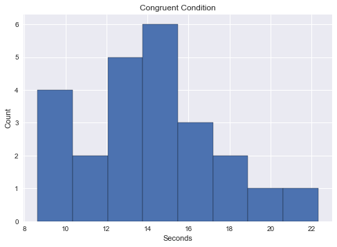

```python
sns.set()
plt.hist(stroop_df["Congruent"], bins = 8, edgecolor='black')
plt.title("Congruent Condition")
plt.xlabel("Seconds")
plt.ylabel("Count")
```

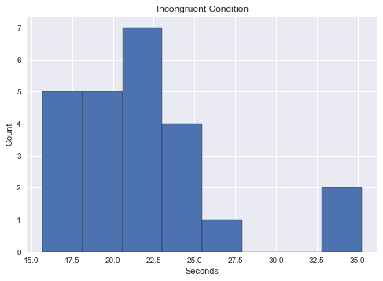

```python
sns.set()
# bin_edges = [8, 9, 10, 11, 12, 13, 14, 15, 16, 17, 18, 19, 20, 21, 22]
plt.hist(stroop_df["Incongruent"], bins = 8, edgecolor='black')
plt.title("Incongruent Condition")
plt.xlabel("Seconds")
plt.ylabel("Count")
```

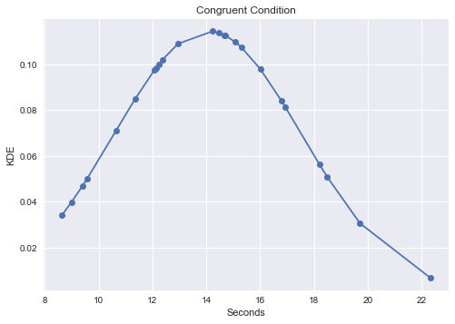

```python
histogram = sorted(stroop_df["Congruent"])
fit = stats.norm.pdf(histogram, np.mean(histogram), np.std(histogram))
pl.plot(histogram,fit,'-o')
plt.title("Congruent Condition")
plt.xlabel("Seconds")
plt.ylabel("KDE")
#Source: https://stackoverflow.com/questions/20011494/plot-normal-distribution-with-matplotlib
```

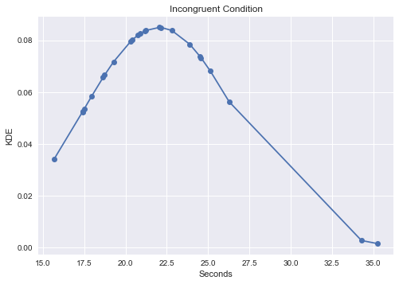

```python
histogram1 = sorted(stroop_df["Incongruent"])
fit = stats.norm.pdf(histogram1, np.mean(histogram1), np.std(histogram1))
pl.plot(histogram1,fit,'-o')
plt.title("Incongruent Condition")
plt.xlabel("Seconds")
plt.ylabel("KDE")
#Source: https://stackoverflow.com/questions/20011494/plot-normal-distribution-with-matplotlib
```

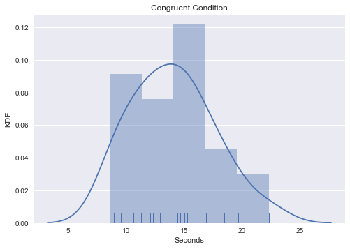

```python
sns.distplot(stroop_df["Congruent"], kde=True, rug=True);
plt.title("Congruent Condition")
plt.xlabel("Seconds")
plt.ylabel("KDE")
#Source: https://seaborn.pydata.org/generated/seaborn.distplot.html
```

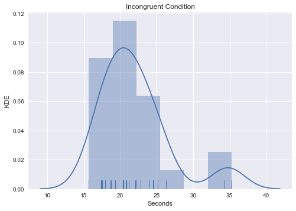

```python
sns.distplot(stroop_df["Incongruent"], kde=True, rug=True);
plt.title("Incongruent Condition")
plt.xlabel("Seconds")
plt.ylabel("KDE")
#Source: https://seaborn.pydata.org/generated/seaborn.distplot.html
```

Using the congruent condition we gather a baseline for individual performance under normal circumstances (the word matches its corresponding text color). From the results above we get a mean completion time of about 14.05 seconds, a standard deviation of about 3.56. We make use of the kernel density estimate to help plot the shape of the distribution by encoding the density of observations. The relevant congruent plots above show a fairly normal distribution with a modest skew to the right. Under the color-to-word congruent condition this exercise essentially becomes a reading exercise with a relatively low cognitive load processing the information. The individuals do not have to consider the word and text color variables independently.

The results from the alternate condition are interesting in that the time it takes to complete this exercise are distributed over a wider range of time and does not appear to be normally distributed. The rug function draws a small vertical tick at each observation. This bespeaks a significant difference in completion rates under the incongruent condition, which has a mean rate of about 22.02 seconds and a standard deviation of 4.80. The distribution in these incongruent plots appear more heavily skewed to the right.

Considering the relatively small sample size, however, it is difficult to be certain of these findings. What we can say about this dataset though is that people appear to have a more difficult time saying the text color aloud when the independent word is different.

#### 5. Now, perform the statistical test and report your results. What is your confidence level and your critical statistic value? Do you reject the null hypothesis or fail to reject it? Come to a conclusion in terms of the experiment task. Did the results match up with your expectations?

With the consideration that the two treatments, congruent and incongruent conditions, are measured for the same sample population a paired-sample t-test will be used here. We will test whether or not the means for the pairs of observation are significantly different. We will use a confidence interval of 90% and our Degrees of Freedom = 23 (df = n-1). The critical t value is 1.714.

We will determine whether or not the null hypothesis can rejected (if there is a statistical significance between the two conditions) by confirming that the calculated test statistic is greater than the critical t value. The t distribution table will help determine the critical t-value: https://s3.amazonaws.com/udacity-hosted-downloads/t-table.jpg

Now let's Calculate the test statistic.

```python
mean_dif = np.mean(stroop_df['Incongruent']) - np.mean(stroop_df['Congruent'])

print(mean_dif)
```

```
7.96479166667
```

Above is the mean difference between incongruent and congruent conditions. Next we will divide the difference in means by the estimated standard error of the mean, calculated below.

```python
ind_dif = stroop_df['Congruent'] - stroop_df['Incongruent']

print(ind_dif)
```

```
0     -7.199
1     -1.950
2    -11.650
3     -7.057
4     -8.134
5     -8.640
6     -9.880
7     -8.407
8    -11.361
9    -11.802
10    -2.196
11    -3.346
12    -2.437
13    -3.401
14   -17.055
15   -10.028
16    -6.644
17    -9.790
18    -6.081
19   -21.919
20   -10.950
21    -3.727
22    -2.348
23    -5.153
dtype: float64
```

```python
sd_dif = np.std(ind_dif, ddof=1)
print(sd_dif)
```

```
4.86482691036
```

```python
se = sd_dif/np.sqrt(24)
print(se)
```

```
0.993028634778
```

```python
test_statistic = mean_dif/se
print(test_statistic)
```

```
8.02070694411
```

As shown in the results of these calculations we see that the test statistic (8.02) is greater than our t value (1.714). Taking into account that this figure has a degrees of freedom of 23 and a confidence interval of 90% we can reject the null hypothesis, concluding that there is a statistically significant difference in the completion time for the task under each condition. This is consistent with my own experience taking the Stroop test.

#### References

Udacity forums

Paired sample t-test: http://www.statisticssolutions.com/manova-analysis-paired-sample-t-test/

For t value: https://s3.amazonaws.com/udacity-hosted-downloads/t-table.jpg

#### 6. Optional: What do you think is responsible for the effects observed? Can you think of an alternative or similar task that would result in a similar effect? Some research about the problem will be helpful for thinking about these two questions!

The observed effects can possibly be attributed to the additional cognitive load involved in processing the information, disregarding the independent word in order to focus on and say aloud the text color. In relation to the distractions that text color can produce, it is standard practice in many publishing style guides to maintain consistent text color (usually in black) throughout a piece of communication in order to facilitate the ease of reading. This test focuses on the color of the text instead of the word which seems to complicate the normal reading process further. If the participant is forced to read and consider, then disregard the meaning of the word and say the text color aloud, it is understandable that this incongruent condition will result in longer processing and essentially completion times.

The potential for exploration on alternative tasks is what has kept this particular test common since it's publication in English in 1935. I think it would be interesting to explore the results among different age demographics performing the task. We could refine further by expanding the population to various countries.